# Usando y Enseñando R para Investigación Reproducible

27 Marzo 2018 R-Ladies Buenos Aires

## La programación es importante porque permite automatizar tareas.

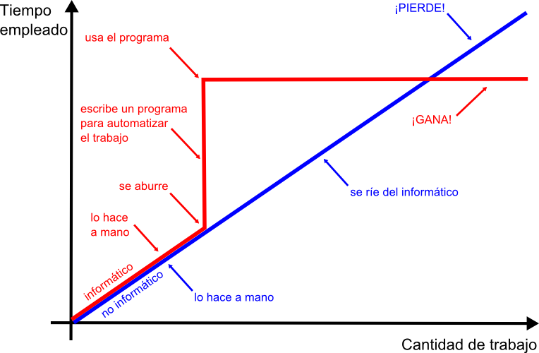

<sup>1</sup>

## R permite estadísticas reproducibles y visualización de datos

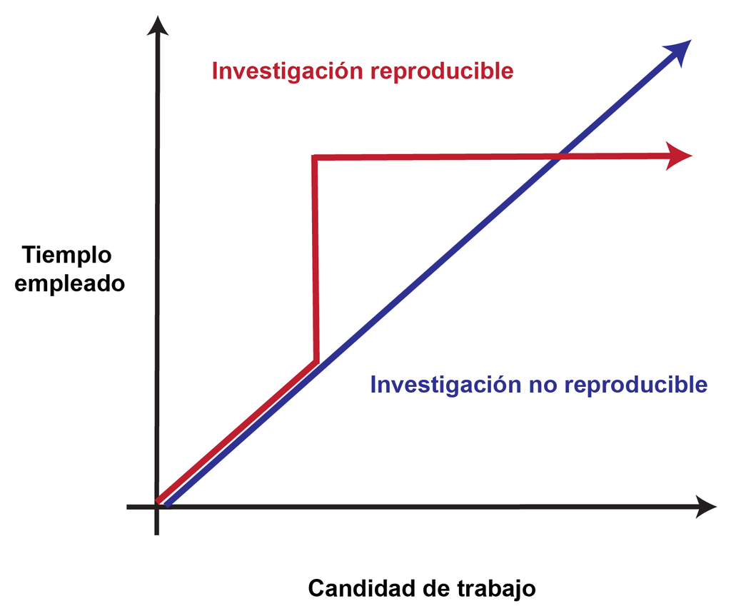

## La enseñanza colaborativa también ahorra tiempo

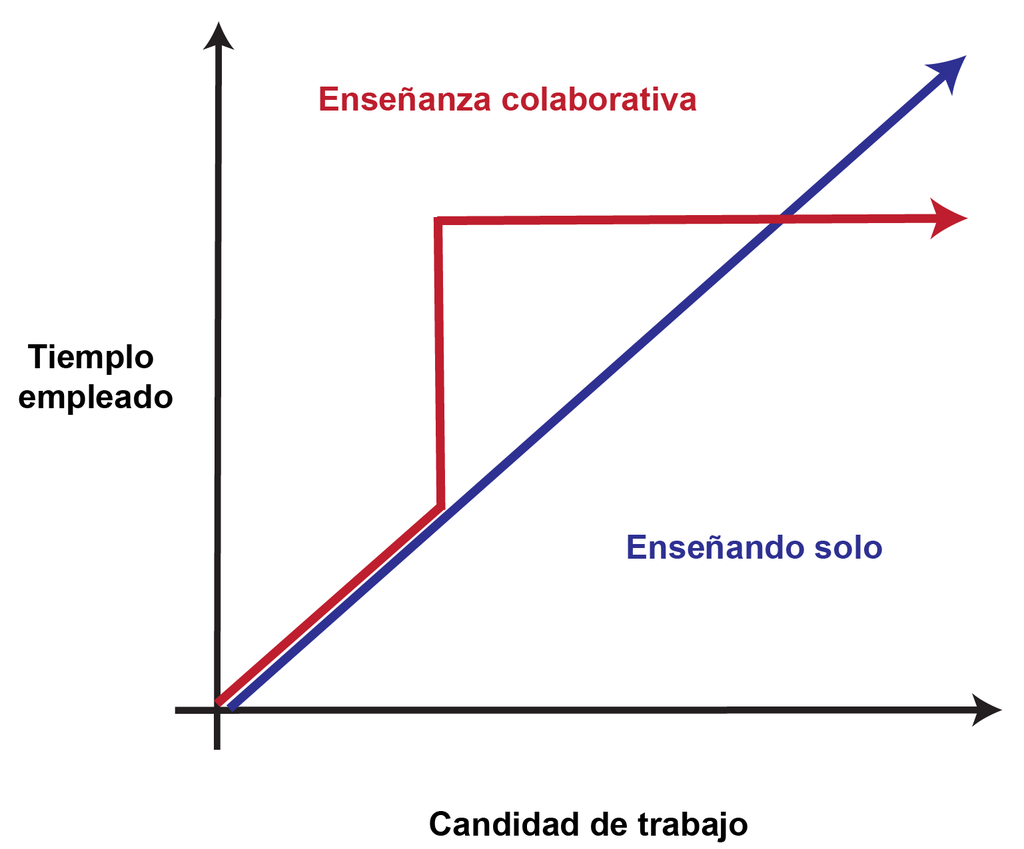

## Mi filosofía

## Mi filosofía

- Yo creo que todos aprenden más cuando la ciencia y la educación están abiertas
- Yo creo que la mejor manera de aprender es enseñando
- Recuerda que nadie es re buena al principio, pero todas mejoramos con la práctica
- Recuerda que vos podés hacer lo que quieras

## Consejo 1: Use *R Markdown* para reproducibilidad y familiarícese con archivos de texto sin formato

<sup>2</sup>

[figure not shown]

<sup>3</sup>

## Consejo 3: Documenta tu flujo de trabajo

Porque probablemente sea único y complejo

[figure not shown]

<sup>4</sup>

## Ejemplo de archivo README.md

[figure not shown]

<sup>5</sup>

## Consejo 4: Desarrolla tu propia paleta de colores

Colorbrewer<sup>6</sup> te ayuda a elegir colores amigables para daltónicos

[figure not shown]

## Ejemplos de paletas de colores

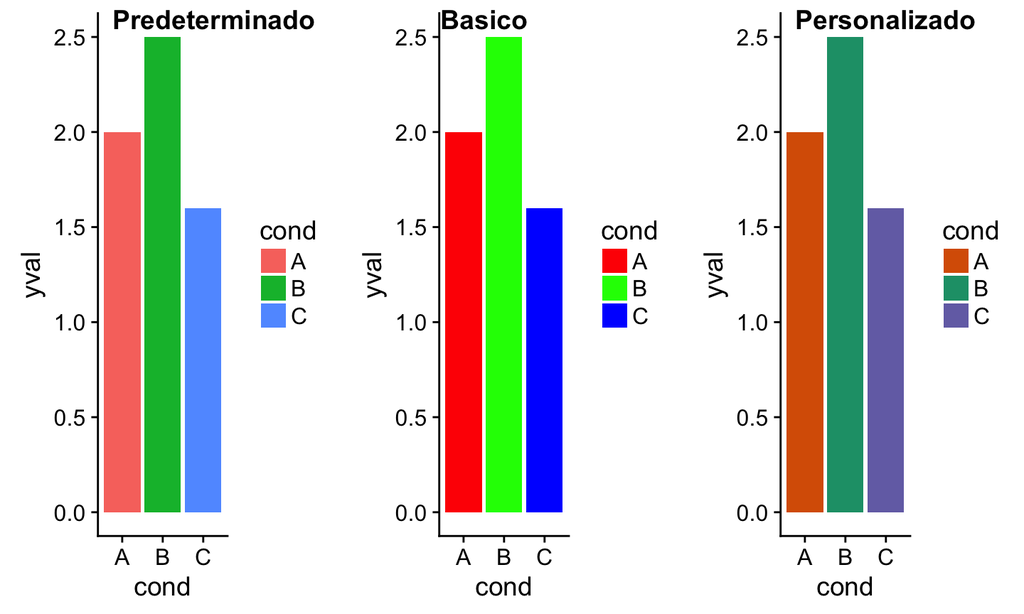

- Basico: `+ scale_fill_manual(values=c("red", "green", "blue"))`
- Personalizado: `+ scale_fill_manual(values=c("#d95f02", "#1b9e77", "#7570b3"))`

## Convertir HEX a RGB si fuera necesario

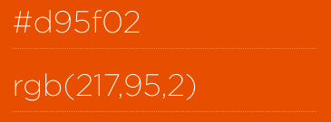

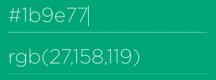

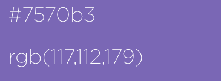

<sup>7</sup>

## Confirmá que tu paleta es amigable con los daltónicos

colorblindr<sup>8</sup> simula deficiencias de visión del color

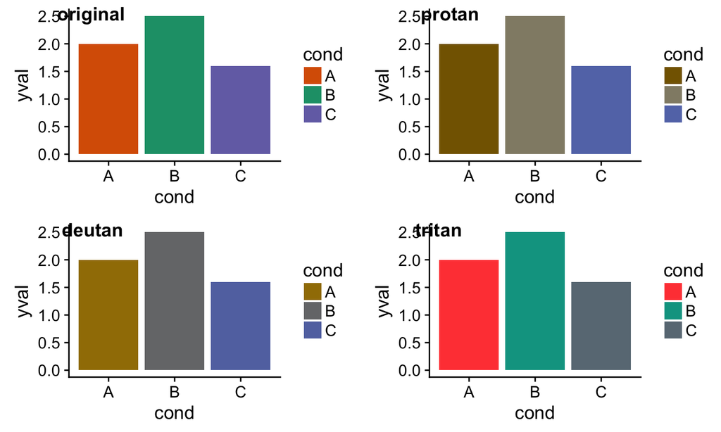

## Consejo 5: Usa leyendas gráficas

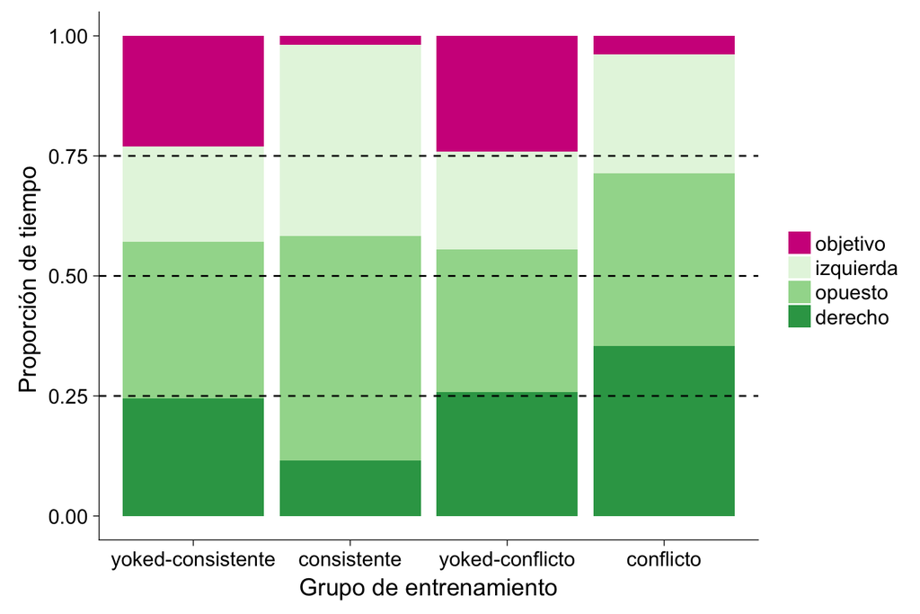

- ¿Qué significa "objetivo", "izquierda", "opuesto" y "derecho"?
- ¿Por qué el rosa "objetivo"?
- ¿Por qué hay líneas discontinuas?

## Consejo 5: Usa leyendas gráficas

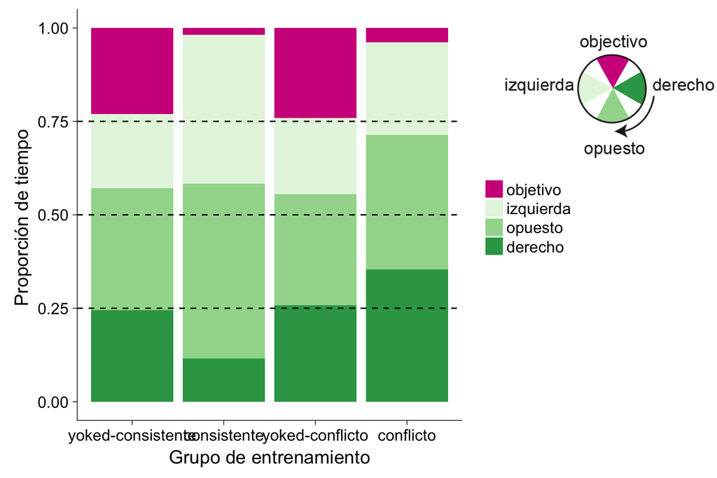

- "objetivo", "izquierda", etc. son cuadrantes de una arena
- Yo quería mostrar un uso desproporcionado del espacio
- Use **cowplot**<sup>9</sup> para agregar imágenes dentro de R

## Punto medio resumen

- Consejo 1: Usa *R Markdown* para la reproducibilidad
- Consejo 2: Usa el control de versiones para la colaboración
- Consejo 3: Documenta tu flujo de trabajo
- Consejo 4: Desarrolla tu propia paleta de colores
- Consejo 5: Usa leyendas gráficas

## Software Carpentry aprovecha el diseño colaborativo de lecciones para enseñar las mejores prácticas para la informática

[figure not shown]

[figure not shown]

[figure not shown]

<sup>10</sup>

## Deseo 1: Me ayudás a mejorar las nuevas lecciones en español de Software Carpentry

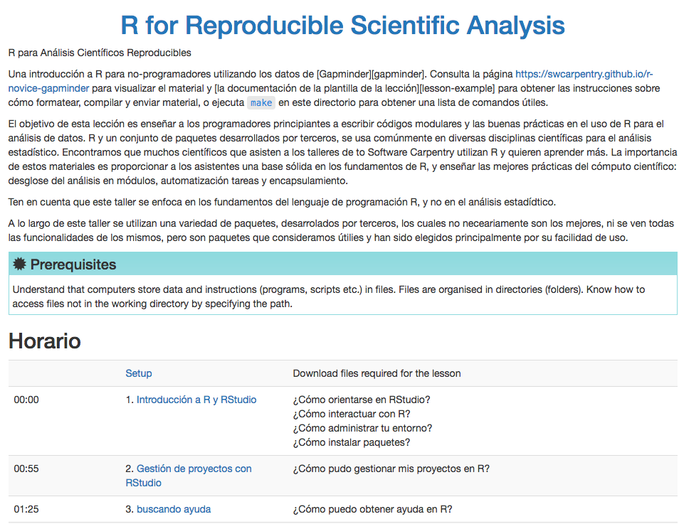

## Como podés ayudarme

- Leer y comentar o editar en GitHub<sup>11</sup>
- Particpar en el **Bug BBQ**<sup>12</sup> el Abril 11 y 12
- Hace videos de vos leyendo y codificando junto con la lección<sup>13</sup>

## Deseo 2: Convertirse en una instructora certificada

- Ahora, no hay instructoras en Argentina :(
- Aplicá aquí: http://carpentries.github.io/instructor-training/

[figure not shown]

<sup>14</sup>

## Deseo 3: ¡Asiste a nuestro primer taller de español!

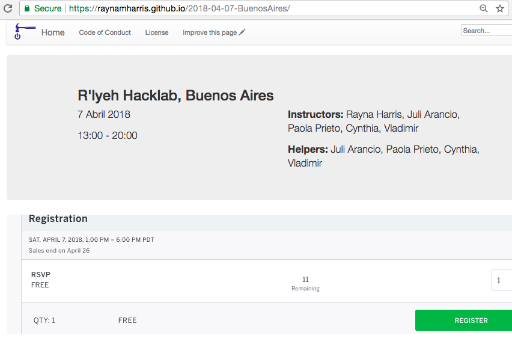

<sup>15</sup>

## Deseo 4: Organizar unos talleres en el futuro

[figure not shown]

<sup>16</sup>

## ¡Gracias por tu atención! ¡Mantengámonos en contacto!

Twitter: @raynamharris

Email: rayna.harris@gmail.com